# Bioreactor time-course analysis

Olivier Chapleur

# Data

In this data set, **three bioreactors** with similar performances were considered as replicates. Different parameters were measured accross time in the three bioreactors.

> Performance data: Based on chemical measurement, the time course evolution of a set of parameters was measured (CH4, C02, acetate, propionate).

> Metabolites data: The time course evolution of 20 selected metabolites was measured with GCMS.

> Microbial data: DNA from samples taken across time was extracted and sequenced. (16S metabarcoding).

# Data preprocessing

> Metabolites (GCMS) data are log transformed.

> Microbial data
1. are filtered (only OTUs with at least 1% of abundance in at least 1 sample are kept = 51 OTUs).
2. a count of 1 sequence is added to each sample/OTU (to avoid 0 in the datamatrix)
3. relative abundance is calculated
4. obtain data is clr transformed

> Performance data is not transformed.

```
## Ther are 51 OTUs after 0.01 % filter
```

# Spline smoothing

All the data are modelled with spline smoothing.

```
## Data-driven Linear Mixed-Effect Model Splines
##  Profiles were modelled for 20 features with  48 time points.
##
##  Basis:
##  [1] "p-spline"
##
##  Knots:
##
##  [1] 17.57143 26.14286 32.71429 38.28571 44.14286 50.57143
##
##  Time points:
##
##   [1] 10 11 12 13 14 15 16 17 18 19 20 21 22 23 24 25 26 27 28 29 30 31 32
## [24] 33 34 35 36 37 38 39 40 41 42 43 44 45 46 47 48 49 50 51 52 53 54 55
## [47] 56 57
##
##  Table of models used to model profiles:
##  0  2  3
## 10  4  6
##
##  Profiles not modelled:
## [1] "All features were modelled"
```

```
## Data-driven Linear Mixed-Effect Model Splines
##  Profiles were modelled for 51 features with  48 time points.
##
##  Basis:
##  [1] "p-spline"
##
##  Knots:
##
##  [1] 17.57143 26.14286 32.71429 38.28571 44.14286 50.57143
##
##  Time points:
##
##   [1] 10 11 12 13 14 15 16 17 18 19 20 21 22 23 24 25 26 27 28 29 30 31 32
## [24] 33 34 35 36 37 38 39 40 41 42 43 44 45 46 47 48 49 50 51 52 53 54 55
## [47] 56 57
##
##  Table of models used to model profiles:
##  0  1  2
## 30 19  2
##
##  Profiles not modelled:
## [1] "All features were modelled"
```

```
## Data-driven Linear Mixed-Effect Model Splines
##  Profiles were modelled for 2 features with  48 time points.
##
##  Basis:
##  [1] "p-spline"
##
##  Knots:
##
##  [1]   5.428571  13.000000  27.142857  44.142857  66.000000 113.000000
##
##  Time points:
##
##   [1] 10 11 12 13 14 15 16 17 18 19 20 21 22 23 24 25 26 27 28 29 30 31 32
## [24] 33 34 35 36 37 38 39 40 41 42 43 44 45 46 47 48 49 50 51 52 53 54 55
## [47] 56 57
##
##  Table of models used to model profiles:
## 1
## 2
##
##  Profiles not modelled:
## [1] "All features were modelled"
```

```
## Data-driven Linear Mixed-Effect Model Splines
##  Profiles were modelled for 2 features with  48 time points.
##
##  Basis:
##  [1] "p-spline"
##
##  Knots:
##
##  [1]  3.5 11.0 19.5 29.0 40.5 57.0 92.5
##
##  Time points:
##
##   [1] 10 11 12 13 14 15 16 17 18 19 20 21 22 23 24 25 26 27 28 29 30 31 32
## [24] 33 34 35 36 37 38 39 40 41 42 43 44 45 46 47 48 49 50 51 52 53 54 55
## [47] 56 57
##
##  Table of models used to model profiles:
## 3
## 2
##
##  Profiles not modelled:
## [1] "All features were modelled"
```

# Filtering of the obtained profiles

## OTUs

```
## # A tibble: 51 x 3
## # Groups:   molecule [?]
##    molecule model_used    MSE
##    <chr>    <fct>       <dbl>
##  1 OTU_1    0          0.0750
##  2 OTU_10   1          0.0235
##  3 OTU_107  0          3.42
##  4 OTU_11   0          0.0553
##  5 OTU_13   1          0.0534
##  6 OTU_130  1          0.377
##  7 OTU_14   0          0.0114
##  8 OTU_15   0          0.267
##  9 OTU_16   0          0.0820
## 10 OTU_169  1          0.162
## # ... with 41 more rows
```

```
##  [1] "OTU_1"   "OTU_10"  "OTU_11"  "OTU_13"  "OTU_130" "OTU_14"  "OTU_15"
##  [8] "OTU_16"  "OTU_169" "OTU_17"  "OTU_18"  "OTU_19"  "OTU_2"   "OTU_20"
## [15] "OTU_21"  "OTU_24"  "OTU_25"  "OTU_26"  "OTU_28"  "OTU_29"  "OTU_30"
## [22] "OTU_304" "OTU_31"  "OTU_35"  "OTU_38"  "OTU_4"   "OTU_41"  "OTU_44"
## [29] "OTU_45"  "OTU_46"  "OTU_5"   "OTU_50"  "OTU_59"  "OTU_6"   "OTU_60"
## [36] "OTU_61"  "OTU_65"  "OTU_68"  "OTU_7"   "OTU_74"  "OTU_75"  "OTU_8"
## [43] "OTU_82"  "OTU_97"
```

| molecule | MSE.filter | modelsUsed | BP.test |
| --- | --- | --- | --- |
| OTU_2 | TRUE | 1 | TRUE |
| OTU_1 | TRUE | 0 | TRUE |
| OTU_4 | TRUE | 0 | TRUE |
| OTU_5 | TRUE | 0 | TRUE |
| OTU_6 | TRUE | 0 | TRUE |
| OTU_7 | TRUE | 2 | TRUE |
| OTU_8 | TRUE | 0 | TRUE |
| OTU_10 | TRUE | 1 | TRUE |
| OTU_11 | TRUE | 0 | TRUE |
| OTU_13 | TRUE | 1 | TRUE |
| OTU_14 | TRUE | 0 | TRUE |
| OTU_15 | TRUE | 0 | TRUE |
| OTU_16 | TRUE | 0 | TRUE |
| OTU_17 | TRUE | 0 | TRUE |
| OTU_18 | TRUE | 0 | TRUE |
| OTU_19 | TRUE | 0 | TRUE |
| OTU_20 | TRUE | 1 | TRUE |
| OTU_21 | TRUE | 0 | TRUE |
| OTU_22 | FALSE | 0 | TRUE |
| OTU_24 | TRUE | 0 | TRUE |
| OTU_25 | TRUE | 0 | TRUE |
| OTU_26 | TRUE | 1 | TRUE |
| OTU_28 | TRUE | 1 | TRUE |
| OTU_29 | TRUE | 0 | TRUE |
| OTU_30 | TRUE | 0 | TRUE |
| OTU_31 | TRUE | 0 | TRUE |
| OTU_33 | TRUE | 0 | FALSE |
| OTU_34 | FALSE | 0 | TRUE |
| OTU_35 | TRUE | 1 | TRUE |
| OTU_38 | TRUE | 1 | TRUE |
| OTU_41 | TRUE | 0 | TRUE |
| OTU_44 | TRUE | 1 | TRUE |
| OTU_45 | TRUE | 0 | TRUE |
| OTU_46 | TRUE | 1 | TRUE |
| OTU_50 | TRUE | 1 | TRUE |
| OTU_51 | FALSE | 0 | TRUE |
| OTU_59 | TRUE | 1 | TRUE |
| OTU_60 | TRUE | 1 | TRUE |
| OTU_61 | TRUE | 2 | TRUE |
| OTU_65 | TRUE | 0 | TRUE |
| OTU_68 | TRUE | 1 | TRUE |
| OTU_74 | TRUE | 1 | TRUE |
| OTU_75 | TRUE | 0 | TRUE |
| OTU_82 | TRUE | 1 | TRUE |
| OTU_84 | FALSE | 0 | TRUE |
| OTU_92 | FALSE | 0 | TRUE |
| OTU_97 | TRUE | 1 | TRUE |
| OTU_107 | FALSE | 0 | TRUE |
| OTU_130 | TRUE | 1 | TRUE |
| OTU_169 | TRUE | 1 | TRUE |
| OTU_304 | TRUE | 0 | TRUE |

```
##  MSE.filter       BP.test
##  Mode :logical   Mode :logical
##  FALSE:6         FALSE:1
##  TRUE :45        TRUE :50
```

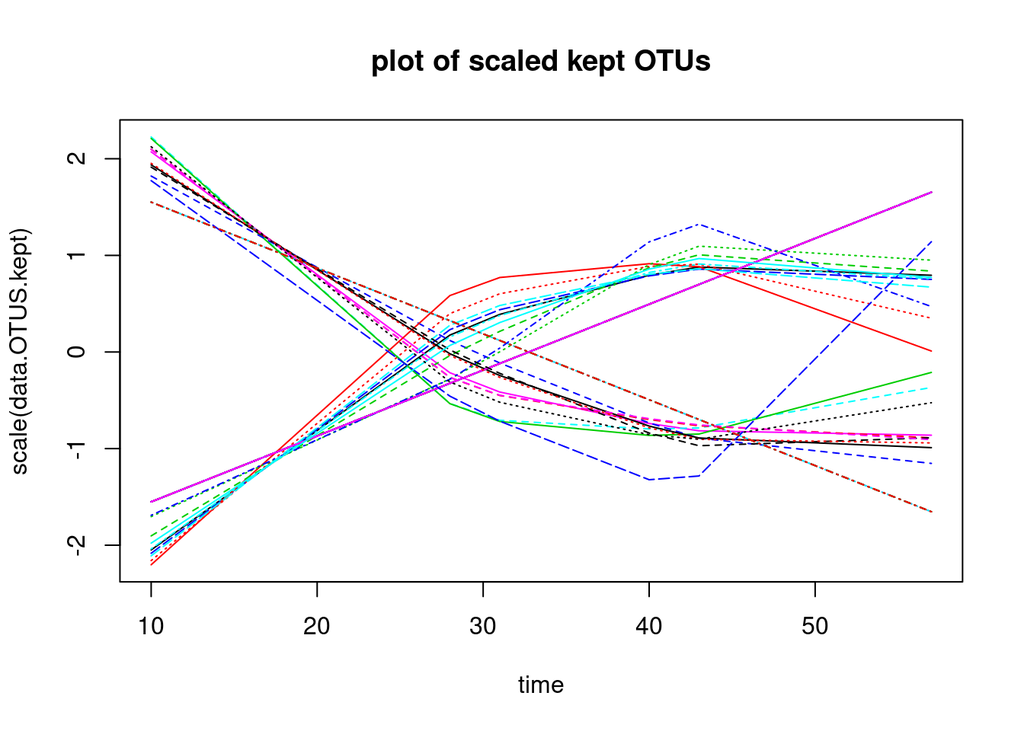

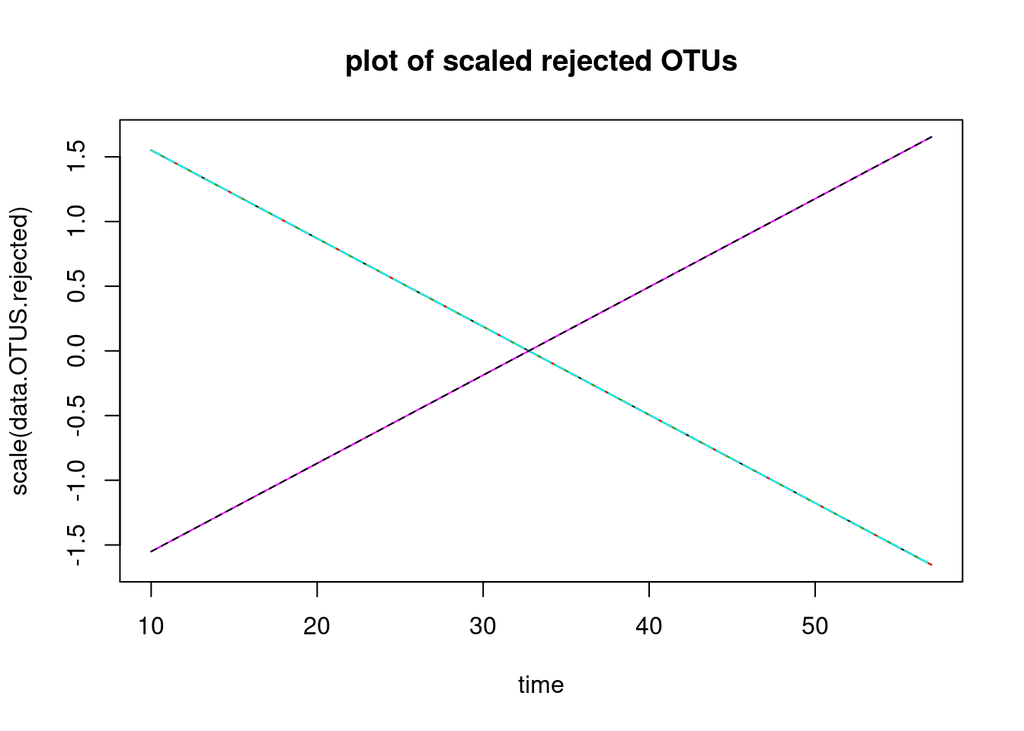

## Metabolites

```
##  [1] "M106T894"  "M179T1018" "M205T1473" "M207T1196" "M229T1227"
##  [6] "M271T1466" "M285T1569" "M290T1524" "M291T1584" "M292T1383"
## [11] "M308T1437" "M310T1500" "M357T2099" "M379T1799" "M398T1643"
## [16] "M415T2220"
```

```
##     molecule modelsUsed BP.test
## 1  M266T1372          0   FALSE
## 2  M271T1466          2    TRUE
## 3  M179T1018          2    TRUE
## 4  M129T1196          0   FALSE
## 5  M207T1196          3    TRUE
## 6   M106T894          0    TRUE
## 7  M308T1437          0    TRUE
## 8  M310T1500          2    TRUE
## 9  M290T1524          3    TRUE
## 10 M285T1569          2    TRUE
## 11 M379T1799          3    TRUE
## 12 M369T1850          0   FALSE
## 13 M357T2099          0    TRUE
## 14 M415T2220          0    TRUE
## 15 M229T1227          3    TRUE
## 16 M205T1473          3    TRUE
## 17 M292T1383          3    TRUE
## 18 M299T1033          0   FALSE
## 19 M291T1584          0    TRUE
## 20 M398T1643          0    TRUE
```

```
##    molecule           modelsUsed   BP.test
##  Length:20          Min.   :0.0   Mode :logical
##  Class :character   1st Qu.:0.0   FALSE:4
##  Mode  :character   Median :1.0   TRUE :16
##                     Mean   :1.3
##                     3rd Qu.:3.0
##                     Max.   :3.0
```

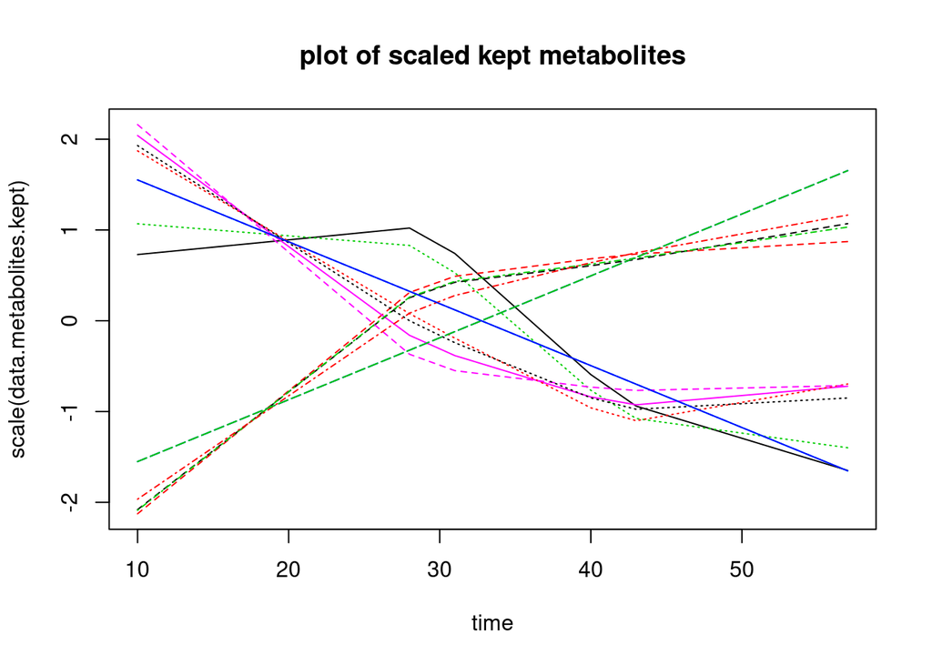

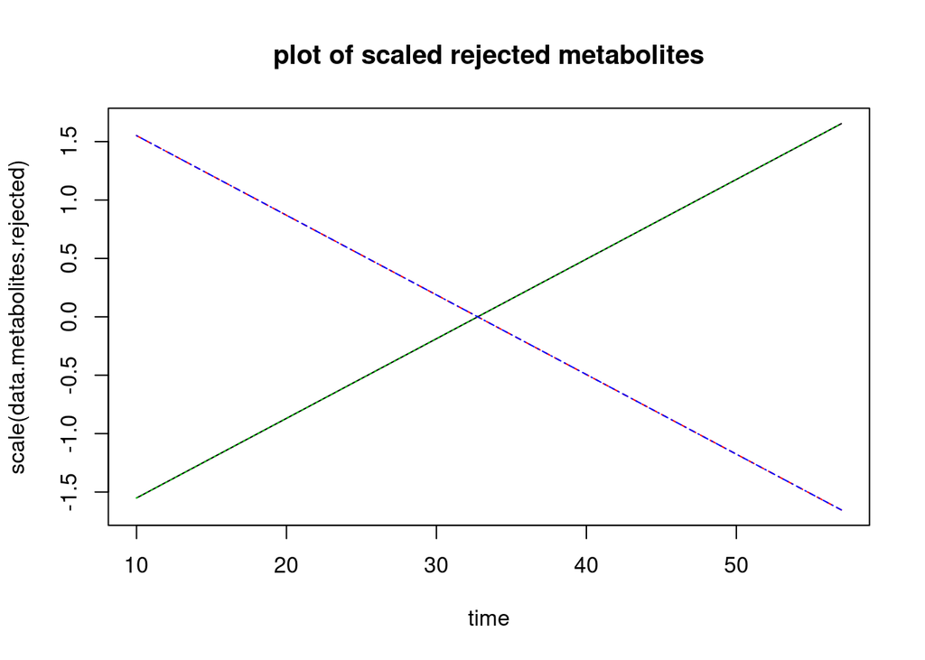

# sPLS

16S data and metabolites are analysed.

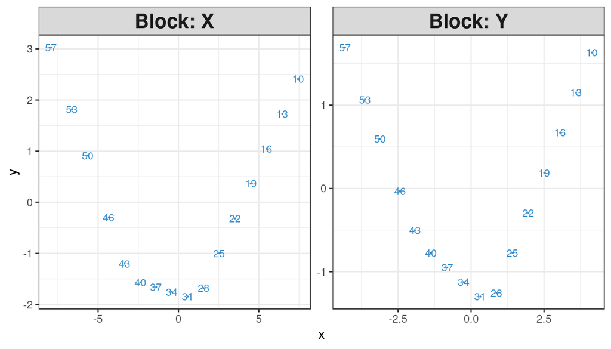

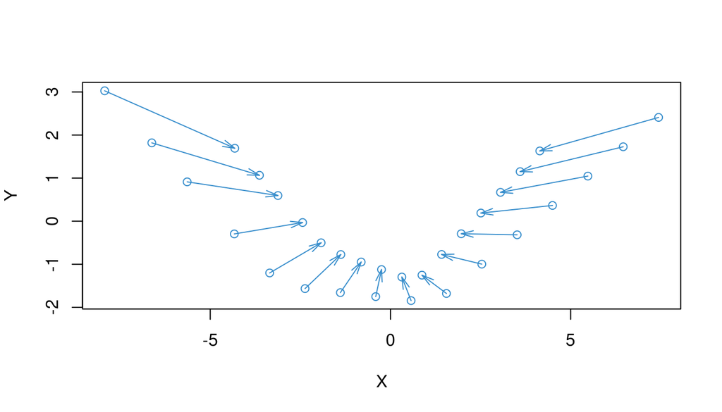

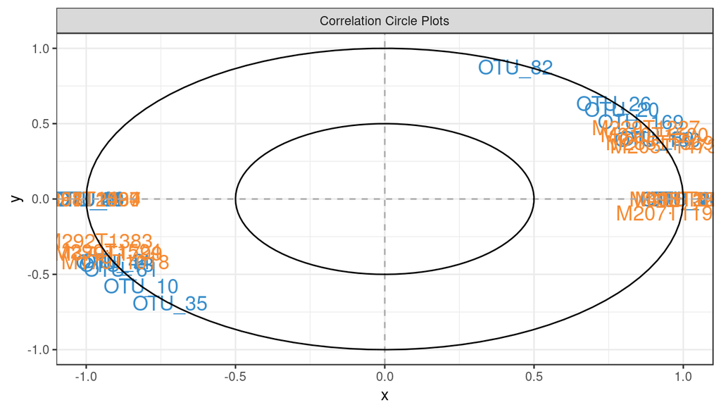

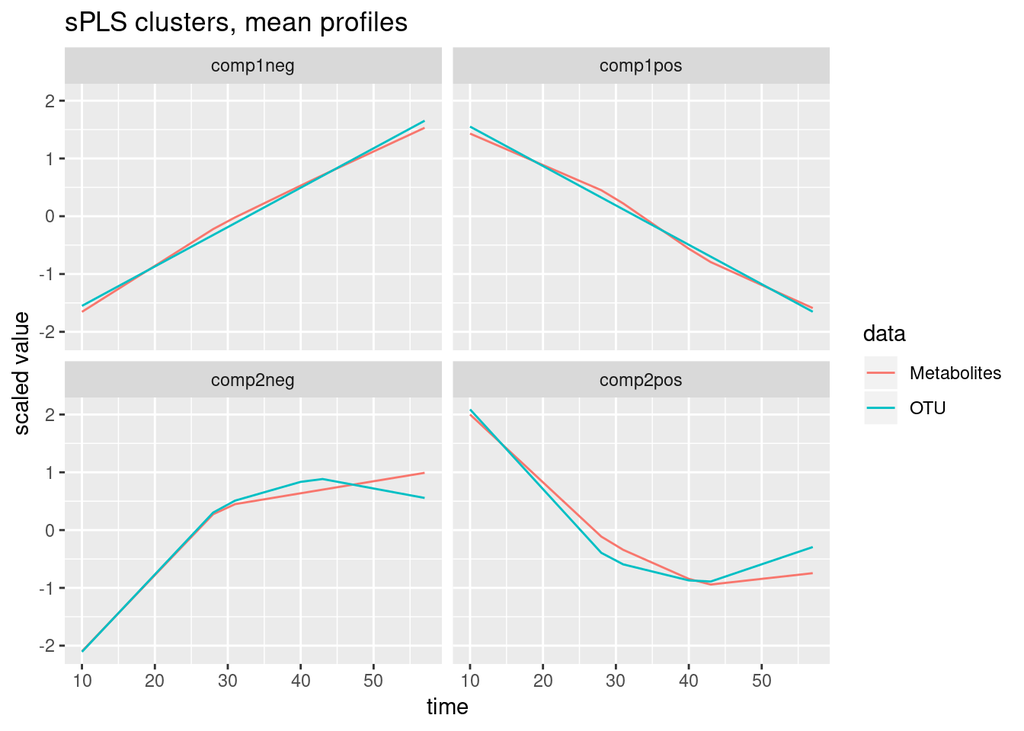

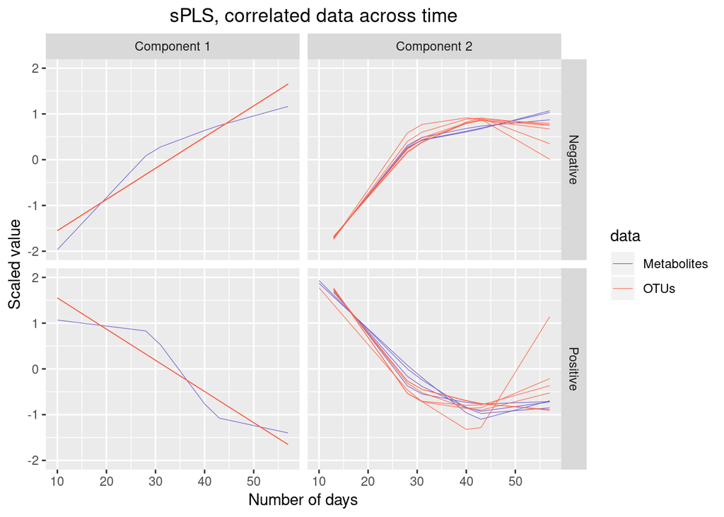

# block sPLS

The three datasets (OTUs, metabolites and performances) are analysed together.

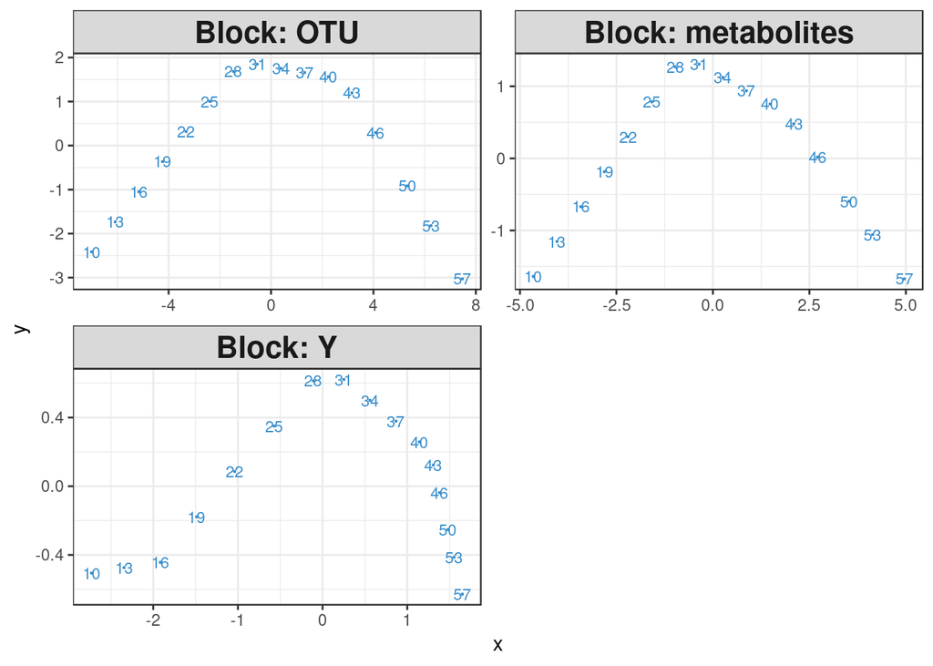

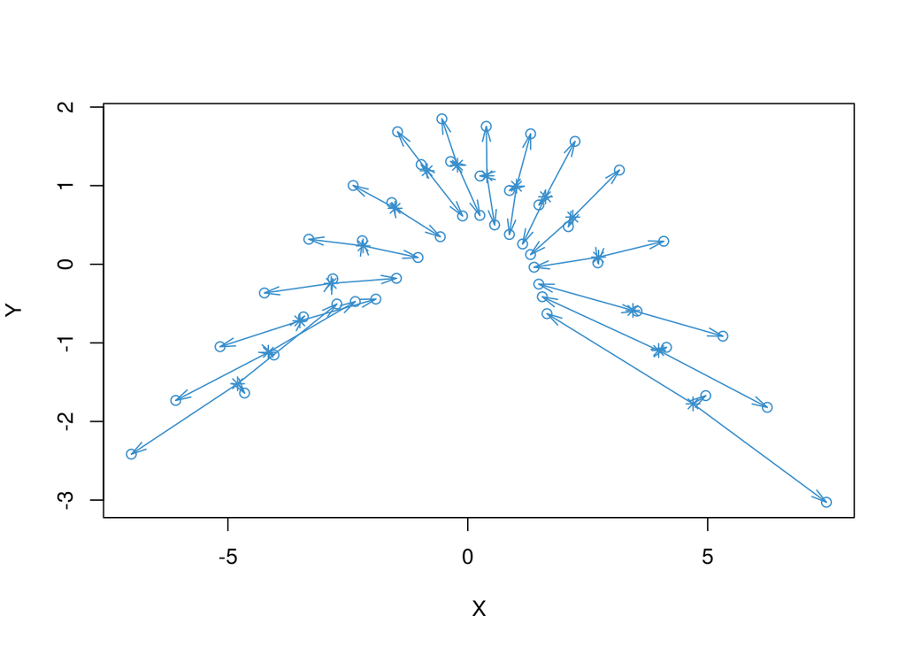

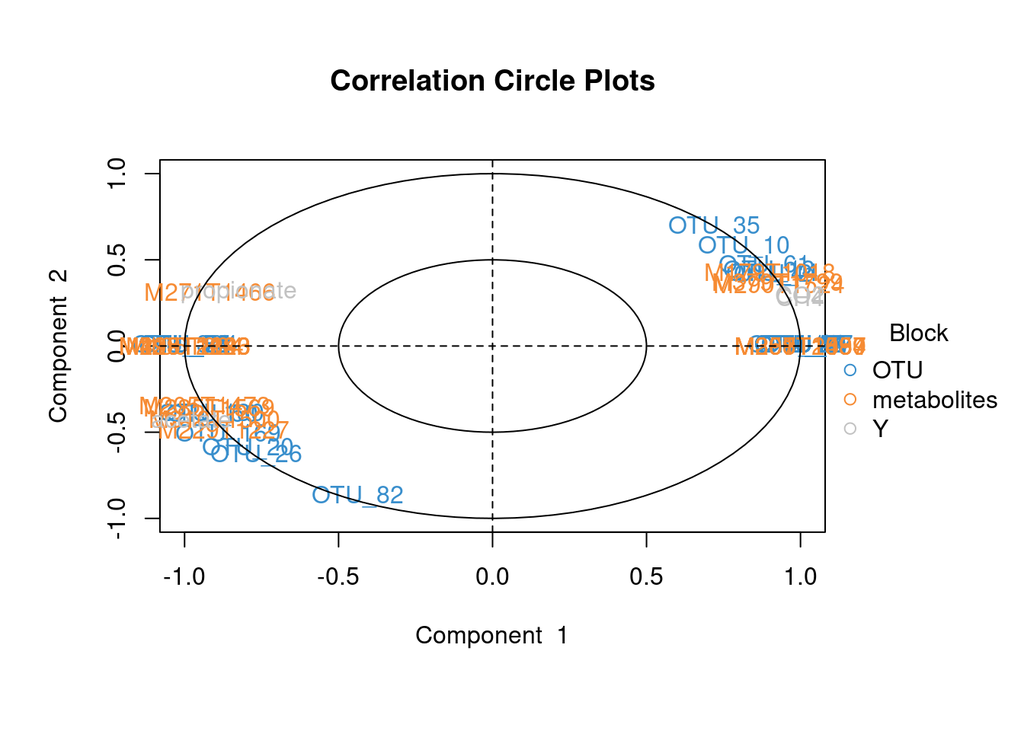

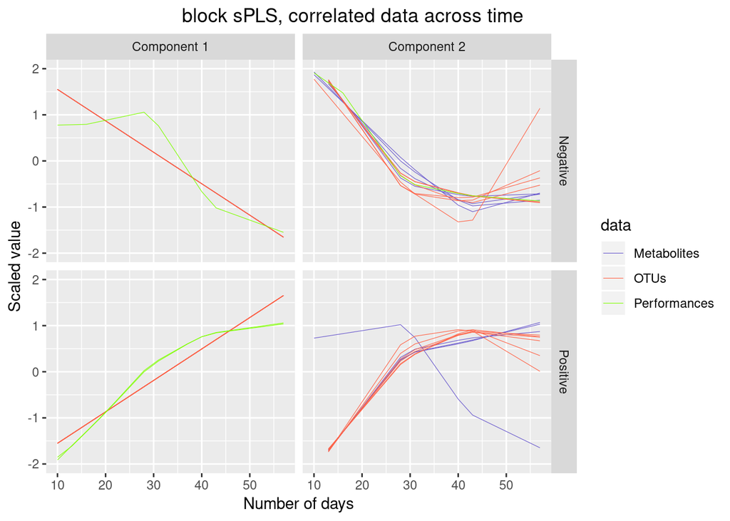

```r
## variables selected with block spls
selected.variables=levels(melt.rgcca$Var1)
non.selected.OTUs=colnames(data.OTUS)[!colnames(data.OTUS)%in%selected.variables]
  non.selected.metabolites=colnames(data.metabolites)[!colnames(data.metabolites)%in%selected.variables]
```